# Analyze_NYCTaxi

## Analyzing NYC Taxi and Limousine Commission (TLC)

The data source is obtained from NYC Taxi and Limousine Commission (TLC) website (https://www1.nyc.gov/site/tlc/about/tlc-trip-record-data.page). There are lot of data available on Yellow and Green Taxis. The data records include fields capturing pick-up and drop-off dates/times, pick-up and drop-off locations, trip distances, itemized fares, rate types, payment types, and driver-reported passenger counts. The data used in the attached datasets were collected and provided to the NYC Taxi and Limousine Commission (TLC) by technology providers authorized under the Taxicab & Livery Passenger Enhancement Programs (TPEP/LPEP)

#### Import the libraries

```python
import numpy as np
import pandas as pd
import math
import datetime
from pandleau import *
from pulp import *
import re
```

```
You are using the Tableau SDK, please save the output as .tde format
```

#### Import the dataset

```python
df = pd.read_csv("yellow_tripdata_2017-06.csv")
df.head(5)
```

|  | VendorID | tpep_pickup_datetime | tpep_dropoff_datetime | passenger_count | trip_distance | RatecodeID | store_and_fwd_flag | PULocationID | DOLocationID | payment_type | fare_amount | extra | mta_tax | tip_amount | tolls_amount | improvement_surcharge | total_amount |
| --- | --- | --- | --- | --- | --- | --- | --- | --- | --- | --- | --- | --- | --- | --- | --- | --- | --- |
| 0 | 2 | 2017-06-08 07:52:31 | 2017-06-08 08:01:32 | 6 | 1.03 | 1 | N | 161 | 140 | 1 | 7.5 | 1.0 | 0.5 | 1.86 | 0.0 | 0.3 | 11.16 |
| 1 | 2 | 2017-06-08 08:08:18 | 2017-06-08 08:14:00 | 6 | 1.03 | 1 | N | 162 | 233 | 1 | 6.0 | 1.0 | 0.5 | 2.34 | 0.0 | 0.3 | 10.14 |
| 2 | 2 | 2017-06-08 08:16:49 | 2017-06-08 15:43:22 | 6 | 5.63 | 1 | N | 137 | 41 | 2 | 21.5 | 1.0 | 0.5 | 0.00 | 0.0 | 0.3 | 23.30 |
| 3 | 2 | 2017-06-29 15:52:35 | 2017-06-29 16:03:27 | 6 | 1.43 | 1 | N | 142 | 48 | 1 | 8.5 | 1.0 | 0.5 | 0.88 | 0.0 | 0.3 | 11.18 |
| 4 | 1 | 2017-06-01 00:00:00 | 2017-06-01 00:03:43 | 1 | 0.60 | 1 | N | 140 | 141 | 1 | 4.5 | 0.5 | 0.5 | 2.00 | 0.0 | 0.3 | 7.80 |

```python
df.shape
```

```
(9656993, 17)
```

```python
df.info()
```

```
<class 'pandas.core.frame.DataFrame'>
RangeIndex: 9656993 entries, 0 to 9656992
Data columns (total 17 columns):
VendorID                 int64
tpep_pickup_datetime     object
tpep_dropoff_datetime    object
passenger_count          int64
trip_distance            float64
RatecodeID               int64
store_and_fwd_flag       object
PULocationID             int64
DOLocationID             int64
payment_type             int64
fare_amount              float64
extra                    float64
mta_tax                  float64
tip_amount               float64
tolls_amount             float64
improvement_surcharge    float64
total_amount             float64
dtypes: float64(8), int64(6), object(3)
memory usage: 1.2+ GB
```

```python
df.describe()
```

|  | VendorID | passenger_count | trip_distance | RatecodeID | PULocationID | DOLocationID | payment_type | fare_amount | extra | mta_tax | tip_amount | tolls_amount | improvement_surcharge | total_amount |
| --- | --- | --- | --- | --- | --- | --- | --- | --- | --- | --- | --- | --- | --- | --- |
| count | 9.656993e+06 | 9.656993e+06 | 9.656993e+06 | 9.656993e+06 | 9.656993e+06 | 9.656993e+06 | 9.656993e+06 | 9.656993e+06 | 9.656993e+06 | 9.656993e+06 | 9.656993e+06 | 9.656993e+06 | 9.656993e+06 | 9.656993e+06 |
| mean | 1.546961e+00 | 1.623943e+00 | 2.978617e+00 | 1.045527e+00 | 1.626235e+02 | 1.607379e+02 | 1.334040e+00 | 1.328727e+01 | 3.413314e-01 | 4.972247e-01 | 1.878480e+00 | 3.376697e-01 | 2.996046e-01 | 1.664632e+01 |
| std | 4.977898e-01 | 1.264608e+00 | 5.704095e+00 | 5.665036e-01 | 6.675223e+01 | 7.047343e+01 | 4.929622e-01 | 2.151675e+02 | 4.623294e-01 | 7.625157e-02 | 2.696221e+00 | 2.022799e+00 | 1.441594e-02 | 2.153387e+02 |
| min | 1.000000e+00 | 0.000000e+00 | 0.000000e+00 | 1.000000e+00 | 1.000000e+00 | 1.000000e+00 | 1.000000e+00 | -5.500000e+02 | -5.056000e+01 | -5.000000e-01 | -7.400000e+01 | -1.250000e+01 | -3.000000e-01 | -5.503000e+02 |
| 25% | 1.000000e+00 | 1.000000e+00 | 1.000000e+00 | 1.000000e+00 | 1.140000e+02 | 1.070000e+02 | 1.000000e+00 | 6.500000e+00 | 0.000000e+00 | 5.000000e-01 | 0.000000e+00 | 0.000000e+00 | 3.000000e-01 | 8.750000e+00 |
| 50% | 2.000000e+00 | 1.000000e+00 | 1.670000e+00 | 1.000000e+00 | 1.620000e+02 | 1.620000e+02 | 1.000000e+00 | 9.500000e+00 | 0.000000e+00 | 5.000000e-01 | 1.360000e+00 | 0.000000e+00 | 3.000000e-01 | 1.185000e+01 |
| 75% | 2.000000e+00 | 2.000000e+00 | 3.100000e+00 | 1.000000e+00 | 2.330000e+02 | 2.330000e+02 | 2.000000e+00 | 1.500000e+01 | 5.000000e-01 | 5.000000e-01 | 2.460000e+00 | 0.000000e+00 | 3.000000e-01 | 1.817000e+01 |
| max | 2.000000e+00 | 9.000000e+00 | 9.496980e+03 | 9.900000e+01 | 2.650000e+02 | 2.650000e+02 | 5.000000e+00 | 6.304618e+05 | 2.250000e+01 | 1.400000e+02 | 4.440000e+02 | 9.900000e+02 | 1.000000e+00 | 6.304631e+05 |

According to the above results, we can see that there are some negative values in the dataset for fare_amount, extra, tip_amount, improvement_surcharge and total_amount (which can be observed by seeing the minimum values). And the minimum passenger count for some of the trips is zero.

```python
pd.options.display.float_format = '{:,.4f}'.format
df_sort_totamount = df.sort_values(by = 'total_amount', ascending = False)
df_sort_totamount.head(10)
```

|  | VendorID | tpep_pickup_datetime | tpep_dropoff_datetime | passenger_count | trip_distance | RatecodeID | store_and_fwd_flag | PULocationID | DOLocationID | payment_type | fare_amount | extra | mta_tax | tip_amount | tolls_amount | improvement_surcharge | total_amount |
| --- | --- | --- | --- | --- | --- | --- | --- | --- | --- | --- | --- | --- | --- | --- | --- | --- | --- |
| 5773420 | 1 | 2017-06-20 22:34:58 | 2017-06-20 22:39:16 | 1 | 0.8000 | 1 | N | 141 | 141 | 2 | 630,461.8200 | 0.5000 | 0.5000 | 0.0000 | 0.0000 | 0.3000 | 630,463.1200 |
| 6007639 | 1 | 2017-06-21 16:58:30 | 2017-06-21 17:26:05 | 1 | 0.0000 | 1 | N | 158 | 161 | 2 | 218,316.3000 | 0.4900 | 0.0000 | 0.0000 | 0.0000 | 0.3000 | 218,317.0900 |
| 3527931 | 1 | 2017-06-14 14:20:34 | 2017-06-14 14:31:56 | 2 | 733.4000 | 2 | N | 186 | 137 | 3 | 12,837.4500 | 0.0000 | 53.8000 | 0.0000 | 0.0000 | 0.0000 | 12,891.2500 |
| 5640037 | 2 | 2017-06-20 15:21:21 | 2017-06-22 11:19:32 | 1 | 9,496.9800 | 1 | N | 193 | 193 | 2 | 9,999.9900 | 0.0000 | 0.0000 | 0.0000 | 0.0000 | 0.0000 | 9,999.9900 |
| 9218988 | 2 | 2017-06-09 16:01:22 | 2017-06-10 09:48:14 | 1 | 4,208.9400 | 1 | N | 193 | 193 | 2 | 9,999.9900 | 0.0000 | 0.0000 | 0.0000 | 0.0000 | 0.0000 | 9,999.9900 |
| 5203847 | 2 | 2017-06-19 09:02:27 | 2017-06-20 15:20:43 | 1 | 6,545.7800 | 1 | N | 193 | 193 | 2 | 9,999.9900 | 0.0000 | 0.0000 | 0.0000 | 0.0000 | 0.0000 | 9,999.9900 |
| 4201741 | 2 | 2017-06-16 11:47:32 | 2017-06-19 08:58:12 | 1 | 4,942.4000 | 1 | N | 193 | 193 | 2 | 9,999.9900 | 0.0000 | 0.0000 | 0.0000 | 0.0000 | 0.0000 | 9,999.9900 |
| 473417 | 1 | 2017-06-11 01:21:35 | 2017-06-11 01:40:50 | 1 | 7.0000 | 1 | N | 264 | 264 | 2 | 8,018.0000 | -50.5600 | 51.3600 | 0.0000 | 0.0000 | 0.0000 | 8,018.8000 |
| 2427507 | 1 | 2017-06-08 11:14:26 | 2017-06-08 11:27:24 | 1 | 3.3000 | 1 | N | 45 | 66 | 2 | 3,010.8000 | -31.6100 | 32.4100 | 0.0000 | 0.0000 | 0.0000 | 3,011.6000 |
| 2767752 | 1 | 2017-06-11 21:45:24 | 2017-06-11 21:45:24 | 1 | 0.0000 | 1 | N | 65 | 264 | 2 | 1,265.5000 | 0.5000 | 0.5000 | 0.0000 | 0.0000 | 0.3000 | 1,266.8000 |

There are some data errors in this dataset. If the data is sorted by total_amount in descending order, we can observe that there is huge amount recorded for small trip distances and zero trip distances.

```python
t1 = pd.to_datetime(df['tpep_pickup_datetime'])
t2 = pd.to_datetime(df['tpep_dropoff_datetime'])

diff = t2 - t1
df['trip_duration'] = diff.dt.total_seconds()
df_sort_tripduration = df.sort_values(by = 'trip_duration')
df_sort_tripduration.head(10)
```

|  | VendorID | tpep_pickup_datetime | tpep_dropoff_datetime | passenger_count | trip_distance | RatecodeID | store_and_fwd_flag | PULocationID | DOLocationID | payment_type | fare_amount | extra | mta_tax | tip_amount | tolls_amount | improvement_surcharge | total_amount | trip_duration |
| --- | --- | --- | --- | --- | --- | --- | --- | --- | --- | --- | --- | --- | --- | --- | --- | --- | --- | --- |
| 1622328 | 1 | 2017-06-04 17:24:03 | 2017-06-04 17:24:03 | 1 | 0.0000 | 1 | N | 145 | 264 | 2 | 7.5000 | 0.0000 | 0.5000 | 0.0000 | 0.0000 | 0.3000 | 8.3000 | 0.0000 |
| 1351028 | 1 | 2017-06-11 13:34:49 | 2017-06-11 13:34:49 | 1 | 0.0000 | 1 | N | 79 | 264 | 2 | 7.0000 | 0.0000 | 0.5000 | 0.0000 | 0.0000 | 0.3000 | 7.8000 | 0.0000 |
| 2062961 | 1 | 2017-06-06 11:23:38 | 2017-06-06 11:23:38 | 1 | 0.0000 | 1 | N | 211 | 264 | 2 | 17.0000 | 0.0000 | 0.5000 | 0.0000 | 0.0000 | 0.3000 | 17.8000 | 0.0000 |
| 2305715 | 1 | 2017-06-07 17:04:59 | 2017-06-07 17:04:59 | 1 | 0.0000 | 2 | N | 132 | 264 | 2 | 52.0000 | 4.5000 | 0.5000 | 0.0000 | 0.0000 | 0.3000 | 57.3000 | 0.0000 |
| 110742 | 1 | 2017-06-10 11:11:01 | 2017-06-10 11:11:01 | 1 | 0.0000 | 1 | N | 236 | 264 | 2 | 8.0000 | 0.0000 | 0.5000 | 0.0000 | 0.0000 | 0.3000 | 8.8000 | 0.0000 |
| 2036117 | 1 | 2017-06-06 08:10:15 | 2017-06-06 08:10:15 | 1 | 0.0000 | 1 | N | 163 | 264 | 2 | 6.0000 | 0.0000 | 0.5000 | 0.0000 | 0.0000 | 0.3000 | 6.8000 | 0.0000 |
| 7266825 | 1 | 2017-06-25 00:23:20 | 2017-06-25 00:23:20 | 1 | 0.0000 | 1 | N | 264 | 264 | 2 | 8.5000 | 0.5000 | 0.5000 | 0.0000 | 0.0000 | 0.3000 | 9.8000 | 0.0000 |
| 5021862 | 1 | 2017-06-18 22:04:57 | 2017-06-18 22:04:57 | 1 | 0.0000 | 1 | N | 79 | 264 | 2 | 2.5000 | 0.5000 | 0.5000 | 0.0000 | 0.0000 | 0.3000 | 3.8000 | 0.0000 |
| 7411557 | 1 | 2017-06-25 15:16:54 | 2017-06-25 15:16:54 | 1 | 0.0000 | 1 | N | 138 | 264 | 2 | 9.5000 | 0.0000 | 0.5000 | 0.0000 | 0.0000 | 0.3000 | 10.3000 | 0.0000 |
| 4427921 | 1 | 2017-06-17 00:09:48 | 2017-06-17 00:09:48 | 1 | 0.0000 | 1 | N | 79 | 264 | 2 | 12.5000 | 0.5000 | 0.5000 | 0.0000 | 0.0000 | 0.3000 | 13.8000 | 0.0000 |

There are lot of records with trip duration as zero. Also, the pickup and drop off points are different with zero trip distance for those records which should be removed from the dataset

In Summary, these are the changes that needs to be done to the data before analyzing:

#### Remove records with negative values

```python
df_negativeval = df[(df['trip_distance'] < 0) | (df['fare_amount'] < 0) | (df['extra'] < 0) | (df['mta_tax'] < 0) | (df['tip_amount'] < 0) | (df['tolls_amount'] < 0) | (df['improvement_surcharge'] < 0) | (df['total_amount'] < 0) | (df['trip_duration'] < 0)]
df_negativeval.shape
```

```
(4718, 18)
```

Drop the negative value rows obtained from the above search

```python
df.drop(df_negativeval.index, inplace = True)
```

```python
df_dataError_1 = df [(df['total_amount'] > 0) & (df['trip_distance'] == 0) & (df['PULocationID'] != df['DOLocationID'])]
df_dataError_1.shape
```

```
(19005, 18)
```

```python
df.drop(df_dataError_1.index, inplace = True)
```

#### Remove the records with different pickup, drop off location and trip duration as zero

```python
df_dataError_2 = df[(df['trip_duration'] == 0) & (df['PULocationID'] != df['DOLocationID'])]
df_dataError_2.shape
```

```
(632, 18)
```

```python
df.drop(df_dataError_2.index, inplace = True)
```

#### Remove the data which contains pick-up datetime or drop-off datetime with year value other than 2017

```python
df['pickup_year'] = t1.dt.year
df[df['pickup_year'] != 2017].shape
```

```
(0, 19)
```

```python
df['dropoff_year'] = t2.dt.year
df[df['dropoff_year'] != 2017].shape
```

```
(0, 20)
```

#### Remove the records with passenger count as zero

```python
df_zeropassengers = df[df['passenger_count'] == 0]
df_zeropassengers.shape
```

```
(489, 20)
```

```python
df.drop(df_zeropassengers.index, inplace = True)
```

```python
df.shape
```

```
(9632149, 20)
```

```python
df.info()
```

```
<class 'pandas.core.frame.DataFrame'>
Int64Index: 9632149 entries, 0 to 9656992
Data columns (total 20 columns):
VendorID                 int64
tpep_pickup_datetime     object
tpep_dropoff_datetime    object
passenger_count          int64
trip_distance            float64
RatecodeID               int64
store_and_fwd_flag       object
PULocationID             int64
DOLocationID             int64
payment_type             int64
fare_amount              float64
extra                    float64
mta_tax                  float64
tip_amount               float64
tolls_amount             float64
improvement_surcharge    float64
total_amount             float64
trip_duration            float64
pickup_year              int64
dropoff_year             int64
dtypes: float64(9), int64(8), object(3)
memory usage: 1.5+ GB
```

#### Add Month, Day, Hour for Pickup and Drop-off

```python
df['Pickup_Month'] = t1.dt.month
df['Pickup_Day'] = t1.dt.dayofweek
df['Pickup_Hour'] = t1.dt.hour
df['Dropoff_Month'] = t2.dt.month
df['Dropoff_Day'] = t2.dt.dayofweek
df['Dropoff_Hour'] = t2.dt.hour
```

```python
df.head(5)
```

|  | VendorID | tpep_pickup_datetime | tpep_dropoff_datetime | passenger_count | trip_distance | RatecodeID | store_and_fwd_flag | PULocationID | DOLocationID | payment_type | ... | total_amount | trip_duration | pickup_year | dropoff_year | Pickup_Month | Pickup_Day | Pickup_Hour | Dropoff_Month | Dropoff_Day | Dropoff_Hour |
| --- | --- | --- | --- | --- | --- | --- | --- | --- | --- | --- | --- | --- | --- | --- | --- | --- | --- | --- | --- | --- | --- |
| 0 | 2 | 2017-06-08 07:52:31 | 2017-06-08 08:01:32 | 6 | 1.0300 | 1 | N | 161 | 140 | 1 | ... | 11.1600 | 541.0000 | 2017 | 2017 | 6 | 3 | 7 | 6 | 3 | 8 |
| 1 | 2 | 2017-06-08 08:08:18 | 2017-06-08 08:14:00 | 6 | 1.0300 | 1 | N | 162 | 233 | 1 | ... | 10.1400 | 342.0000 | 2017 | 2017 | 6 | 3 | 8 | 6 | 3 | 8 |
| 2 | 2 | 2017-06-08 08:16:49 | 2017-06-08 15:43:22 | 6 | 5.6300 | 1 | N | 137 | 41 | 2 | ... | 23.3000 | 26,793.0000 | 2017 | 2017 | 6 | 3 | 8 | 6 | 3 | 15 |
| 3 | 2 | 2017-06-29 15:52:35 | 2017-06-29 16:03:27 | 6 | 1.4300 | 1 | N | 142 | 48 | 1 | ... | 11.1800 | 652.0000 | 2017 | 2017 | 6 | 3 | 15 | 6 | 3 | 16 |
| 4 | 1 | 2017-06-01 00:00:00 | 2017-06-01 00:03:43 | 1 | 0.6000 | 1 | N | 140 | 141 | 1 | ... | 7.8000 | 223.0000 | 2017 | 2017 | 6 | 3 | 0 | 6 | 3 | 0 |

5 rows × 26 columns

#### Add Pick-up and Drop-off zone according to the LocationID

```python
df_zonelookup = pd.read_csv("taxi+_zone_lookup.csv")
df_zonelookup.head(5)
```

|  | LocationID | Borough | Zone | service_zone |
| --- | --- | --- | --- | --- |
| 0 | 1 | EWR | Newark Airport | EWR |
| 1 | 2 | Queens | Jamaica Bay | Boro Zone |
| 2 | 3 | Bronx | Allerton/Pelham Gardens | Boro Zone |
| 3 | 4 | Manhattan | Alphabet City | Yellow Zone |
| 4 | 5 | Staten Island | Arden Heights | Boro Zone |

```python
df = pd.merge(df, df_zonelookup[['LocationID','Borough']], left_on = 'PULocationID', right_on = 'LocationID', how = 'inner', suffixes = ('', '_Pickup'))
df.head(5)
```

|  | VendorID | tpep_pickup_datetime | tpep_dropoff_datetime | passenger_count | trip_distance | RatecodeID | store_and_fwd_flag | PULocationID | DOLocationID | payment_type | ... | pickup_year | dropoff_year | Pickup_Month | Pickup_Day | Pickup_Hour | Dropoff_Month | Dropoff_Day | Dropoff_Hour | LocationID | Borough |
| --- | --- | --- | --- | --- | --- | --- | --- | --- | --- | --- | --- | --- | --- | --- | --- | --- | --- | --- | --- | --- | --- |
| 0 | 2 | 2017-06-08 07:52:31 | 2017-06-08 08:01:32 | 6 | 1.0300 | 1 | N | 161 | 140 | 1 | ... | 2017 | 2017 | 6 | 3 | 7 | 6 | 3 | 8 | 161 | Manhattan |
| 1 | 2 | 2017-06-01 00:00:06 | 2017-06-01 00:11:30 | 2 | 1.6700 | 1 | N | 161 | 246 | 1 | ... | 2017 | 2017 | 6 | 3 | 0 | 6 | 3 | 0 | 161 | Manhattan |
| 2 | 1 | 2017-06-01 00:00:21 | 2017-06-01 00:06:52 | 1 | 2.0000 | 1 | N | 161 | 113 | 1 | ... | 2017 | 2017 | 6 | 3 | 0 | 6 | 3 | 0 | 161 | Manhattan |
| 3 | 2 | 2017-06-01 00:00:27 | 2017-06-01 00:08:41 | 1 | 1.1400 | 1 | N | 161 | 229 | 1 | ... | 2017 | 2017 | 6 | 3 | 0 | 6 | 3 | 0 | 161 | Manhattan |
| 4 | 1 | 2017-06-01 00:00:44 | 2017-06-01 00:29:36 | 1 | 8.5000 | 1 | N | 161 | 25 | 1 | ... | 2017 | 2017 | 6 | 3 | 0 | 6 | 3 | 0 | 161 | Manhattan |

5 rows × 28 columns

```python
df = pd.merge(df, df_zonelookup[['LocationID','Borough']], left_on = 'DOLocationID', right_on = 'LocationID', how = 'inner', suffixes = ('', '_Dropoff'))
df.head(5)
```

|  | VendorID | tpep_pickup_datetime | tpep_dropoff_datetime | passenger_count | trip_distance | RatecodeID | store_and_fwd_flag | PULocationID | DOLocationID | payment_type | ... | Pickup_Month | Pickup_Day | Pickup_Hour | Dropoff_Month | Dropoff_Day | Dropoff_Hour | LocationID | Borough | LocationID_Dropoff | Borough_Dropoff |
| --- | --- | --- | --- | --- | --- | --- | --- | --- | --- | --- | --- | --- | --- | --- | --- | --- | --- | --- | --- | --- | --- |
| 0 | 2 | 2017-06-08 07:52:31 | 2017-06-08 08:01:32 | 6 | 1.0300 | 1 | N | 161 | 140 | 1 | ... | 6 | 3 | 7 | 6 | 3 | 8 | 161 | Manhattan | 140 | Manhattan |
| 1 | 1 | 2017-06-09 17:59:47 | 2017-06-09 18:10:44 | 1 | 1.7000 | 1 | N | 161 | 140 | 1 | ... | 6 | 4 | 17 | 6 | 4 | 18 | 161 | Manhattan | 140 | Manhattan |
| 2 | 1 | 2017-06-09 18:00:46 | 2017-06-09 18:09:10 | 1 | 1.3000 | 1 | N | 161 | 140 | 1 | ... | 6 | 4 | 18 | 6 | 4 | 18 | 161 | Manhattan | 140 | Manhattan |
| 3 | 1 | 2017-06-09 18:02:09 | 2017-06-09 18:13:21 | 2 | 1.4000 | 1 | N | 161 | 140 | 2 | ... | 6 | 4 | 18 | 6 | 4 | 18 | 161 | Manhattan | 140 | Manhattan |
| 4 | 1 | 2017-06-09 18:05:18 | 2017-06-09 18:20:21 | 1 | 2.3000 | 1 | N | 161 | 140 | 2 | ... | 6 | 4 | 18 | 6 | 4 | 18 | 161 | Manhattan | 140 | Manhattan |

5 rows × 30 columns

```python
df = df.drop(['LocationID', 'LocationID_Dropoff'], axis=1)
```

```python
df.head(5)
```

|  | VendorID | tpep_pickup_datetime | tpep_dropoff_datetime | passenger_count | trip_distance | RatecodeID | store_and_fwd_flag | PULocationID | DOLocationID | payment_type | ... | pickup_year | dropoff_year | Pickup_Month | Pickup_Day | Pickup_Hour | Dropoff_Month | Dropoff_Day | Dropoff_Hour | Borough | Borough_Dropoff |
| --- | --- | --- | --- | --- | --- | --- | --- | --- | --- | --- | --- | --- | --- | --- | --- | --- | --- | --- | --- | --- | --- |
| 0 | 2 | 2017-06-08 07:52:31 | 2017-06-08 08:01:32 | 6 | 1.0300 | 1 | N | 161 | 140 | 1 | ... | 2017 | 2017 | 6 | 3 | 7 | 6 | 3 | 8 | Manhattan | Manhattan |
| 1 | 1 | 2017-06-09 17:59:47 | 2017-06-09 18:10:44 | 1 | 1.7000 | 1 | N | 161 | 140 | 1 | ... | 2017 | 2017 | 6 | 4 | 17 | 6 | 4 | 18 | Manhattan | Manhattan |
| 2 | 1 | 2017-06-09 18:00:46 | 2017-06-09 18:09:10 | 1 | 1.3000 | 1 | N | 161 | 140 | 1 | ... | 2017 | 2017 | 6 | 4 | 18 | 6 | 4 | 18 | Manhattan | Manhattan |
| 3 | 1 | 2017-06-09 18:02:09 | 2017-06-09 18:13:21 | 2 | 1.4000 | 1 | N | 161 | 140 | 2 | ... | 2017 | 2017 | 6 | 4 | 18 | 6 | 4 | 18 | Manhattan | Manhattan |
| 4 | 1 | 2017-06-09 18:05:18 | 2017-06-09 18:20:21 | 1 | 2.3000 | 1 | N | 161 | 140 | 2 | ... | 2017 | 2017 | 6 | 4 | 18 | 6 | 4 | 18 | Manhattan | Manhattan |

5 rows × 28 columns

```python
df = df.rename(columns = {'Borough': 'Borough_Pickup'})
df.head(5)
```

|  | VendorID | tpep_pickup_datetime | tpep_dropoff_datetime | passenger_count | trip_distance | RatecodeID | store_and_fwd_flag | PULocationID | DOLocationID | payment_type | ... | pickup_year | dropoff_year | Pickup_Month | Pickup_Day | Pickup_Hour | Dropoff_Month | Dropoff_Day | Dropoff_Hour | Borough_Pickup | Borough_Dropoff |
| --- | --- | --- | --- | --- | --- | --- | --- | --- | --- | --- | --- | --- | --- | --- | --- | --- | --- | --- | --- | --- | --- |
| 0 | 2 | 2017-06-08 07:52:31 | 2017-06-08 08:01:32 | 6 | 1.0300 | 1 | N | 161 | 140 | 1 | ... | 2017 | 2017 | 6 | 3 | 7 | 6 | 3 | 8 | Manhattan | Manhattan |
| 1 | 1 | 2017-06-09 17:59:47 | 2017-06-09 18:10:44 | 1 | 1.7000 | 1 | N | 161 | 140 | 1 | ... | 2017 | 2017 | 6 | 4 | 17 | 6 | 4 | 18 | Manhattan | Manhattan |
| 2 | 1 | 2017-06-09 18:00:46 | 2017-06-09 18:09:10 | 1 | 1.3000 | 1 | N | 161 | 140 | 1 | ... | 2017 | 2017 | 6 | 4 | 18 | 6 | 4 | 18 | Manhattan | Manhattan |
| 3 | 1 | 2017-06-09 18:02:09 | 2017-06-09 18:13:21 | 2 | 1.4000 | 1 | N | 161 | 140 | 2 | ... | 2017 | 2017 | 6 | 4 | 18 | 6 | 4 | 18 | Manhattan | Manhattan |
| 4 | 1 | 2017-06-09 18:05:18 | 2017-06-09 18:20:21 | 1 | 2.3000 | 1 | N | 161 | 140 | 2 | ... | 2017 | 2017 | 6 | 4 | 18 | 6 | 4 | 18 | Manhattan | Manhattan |

5 rows × 28 columns

#### Add tip rate by calculating the rate of tip_amount by total_amount

```python
df['tip_rate'] = (df['tip_amount']/df['total_amount'])*100
df.head(5)
```

|  | VendorID | tpep_pickup_datetime | tpep_dropoff_datetime | passenger_count | trip_distance | RatecodeID | store_and_fwd_flag | PULocationID | DOLocationID | payment_type | ... | dropoff_year | Pickup_Month | Pickup_Day | Pickup_Hour | Dropoff_Month | Dropoff_Day | Dropoff_Hour | Borough_Pickup | Borough_Dropoff | tip_rate |
| --- | --- | --- | --- | --- | --- | --- | --- | --- | --- | --- | --- | --- | --- | --- | --- | --- | --- | --- | --- | --- | --- |
| 0 | 2 | 2017-06-08 07:52:31 | 2017-06-08 08:01:32 | 6 | 1.0300 | 1 | N | 161 | 140 | 1 | ... | 2017 | 6 | 3 | 7 | 6 | 3 | 8 | Manhattan | Manhattan | 16.6667 |
| 1 | 1 | 2017-06-09 17:59:47 | 2017-06-09 18:10:44 | 1 | 1.7000 | 1 | N | 161 | 140 | 1 | ... | 2017 | 6 | 4 | 17 | 6 | 4 | 18 | Manhattan | Manhattan | 16.6023 |
| 2 | 1 | 2017-06-09 18:00:46 | 2017-06-09 18:09:10 | 1 | 1.3000 | 1 | N | 161 | 140 | 1 | ... | 2017 | 6 | 4 | 18 | 6 | 4 | 18 | Manhattan | Manhattan | 16.5919 |
| 3 | 1 | 2017-06-09 18:02:09 | 2017-06-09 18:13:21 | 2 | 1.4000 | 1 | N | 161 | 140 | 2 | ... | 2017 | 6 | 4 | 18 | 6 | 4 | 18 | Manhattan | Manhattan | 0.0000 |
| 4 | 1 | 2017-06-09 18:05:18 | 2017-06-09 18:20:21 | 1 | 2.3000 | 1 | N | 161 | 140 | 2 | ... | 2017 | 6 | 4 | 18 | 6 | 4 | 18 | Manhattan | Manhattan | 0.0000 |

5 rows × 29 columns

#### Remove or Replace Null values with zero if any found

```python
print (df.isnull().sum())
```

```
VendorID                   0
tpep_pickup_datetime       0
tpep_dropoff_datetime      0
passenger_count            0
trip_distance              0
RatecodeID                 0
store_and_fwd_flag         0
PULocationID               0
DOLocationID               0
payment_type               0
fare_amount                0
extra                      0
mta_tax                    0
tip_amount                 0
tolls_amount               0
improvement_surcharge      0
total_amount               0
trip_duration              0
pickup_year                0
dropoff_year               0
Pickup_Month               0
Pickup_Day                 0
Pickup_Hour                0
Dropoff_Month              0
Dropoff_Day                0
Dropoff_Hour               0
Borough_Pickup             0
Borough_Dropoff            0
tip_rate                 909
dtype: int64
```

```python
df['tip_rate'].fillna(0, inplace=True)
df[df['tip_rate'].isnull()]
```

|  | VendorID | tpep_pickup_datetime | tpep_dropoff_datetime | passenger_count | trip_distance | RatecodeID | store_and_fwd_flag | PULocationID | DOLocationID | payment_type | ... | dropoff_year | Pickup_Month | Pickup_Day | Pickup_Hour | Dropoff_Month | Dropoff_Day | Dropoff_Hour | Borough_Pickup | Borough_Dropoff | tip_rate |
| --- | --- | --- | --- | --- | --- | --- | --- | --- | --- | --- | --- | --- | --- | --- | --- | --- | --- | --- | --- | --- | --- |

0 rows × 29 columns

Convert the Pickup_Day and Dropoff_Day from integer to Day string values (i.e Monday, Tuesday etc.) which makes it easier for analyzing the data

```python
dayofWeek = {0: 'Monday', 1: 'Tuesday', 2: 'Wednesday', 3: 'Thursday', 4: 'Friday', 5: 'Saturday', 6: 'Sunday'}
df.Pickup_Day = [dayofWeek[item] for item in df.Pickup_Day]
df.Dropoff_Day = [dayofWeek[item] for item in df.Dropoff_Day]
df.head(5)
```

|  | VendorID | tpep_pickup_datetime | tpep_dropoff_datetime | passenger_count | trip_distance | RatecodeID | store_and_fwd_flag | PULocationID | DOLocationID | payment_type | ... | dropoff_year | Pickup_Month | Pickup_Day | Pickup_Hour | Dropoff_Month | Dropoff_Day | Dropoff_Hour | Borough_Pickup | Borough_Dropoff | tip_rate |
| --- | --- | --- | --- | --- | --- | --- | --- | --- | --- | --- | --- | --- | --- | --- | --- | --- | --- | --- | --- | --- | --- |
| 0 | 2 | 2017-06-08 07:52:31 | 2017-06-08 08:01:32 | 6 | 1.0300 | 1 | N | 161 | 140 | 1 | ... | 2017 | 6 | Thursday | 7 | 6 | Thursday | 8 | Manhattan | Manhattan | 16.6667 |
| 1 | 1 | 2017-06-09 17:59:47 | 2017-06-09 18:10:44 | 1 | 1.7000 | 1 | N | 161 | 140 | 1 | ... | 2017 | 6 | Friday | 17 | 6 | Friday | 18 | Manhattan | Manhattan | 16.6023 |
| 2 | 1 | 2017-06-09 18:00:46 | 2017-06-09 18:09:10 | 1 | 1.3000 | 1 | N | 161 | 140 | 1 | ... | 2017 | 6 | Friday | 18 | 6 | Friday | 18 | Manhattan | Manhattan | 16.5919 |
| 3 | 1 | 2017-06-09 18:02:09 | 2017-06-09 18:13:21 | 2 | 1.4000 | 1 | N | 161 | 140 | 2 | ... | 2017 | 6 | Friday | 18 | 6 | Friday | 18 | Manhattan | Manhattan | 0.0000 |
| 4 | 1 | 2017-06-09 18:05:18 | 2017-06-09 18:20:21 | 1 | 2.3000 | 1 | N | 161 | 140 | 2 | ... | 2017 | 6 | Friday | 18 | 6 | Friday | 18 | Manhattan | Manhattan | 0.0000 |

5 rows × 29 columns

#### Group the dataframe by Pickup_Day and total_amount to get the total amount earned and number of rides per day of week

```python
df_dayGroup = df.groupby(['Pickup_Day']).agg({'total_amount': ['sum','count']})
df_dayGroup
```

| Pickup_Day | total_amount sum | total_amount count |
| --- | --- | --- |
| Friday | 27,750,630.3104 | 1671143 |
| Monday | 20,120,603.8802 | 1209315 |
| Saturday | 20,072,702.7502 | 1312431 |
| Sunday | 18,548,347.9802 | 1100822 |
| Thursday | 28,833,810.0704 | 1693502 |
| Tuesday | 22,288,382.3602 | 1312057 |
| Wednesday | 22,471,672.4702 | 1332879 |

```python
df.to_csv('df_csv.csv', encoding='utf-8', index=False)
```

#### Find the number of rides per day of week

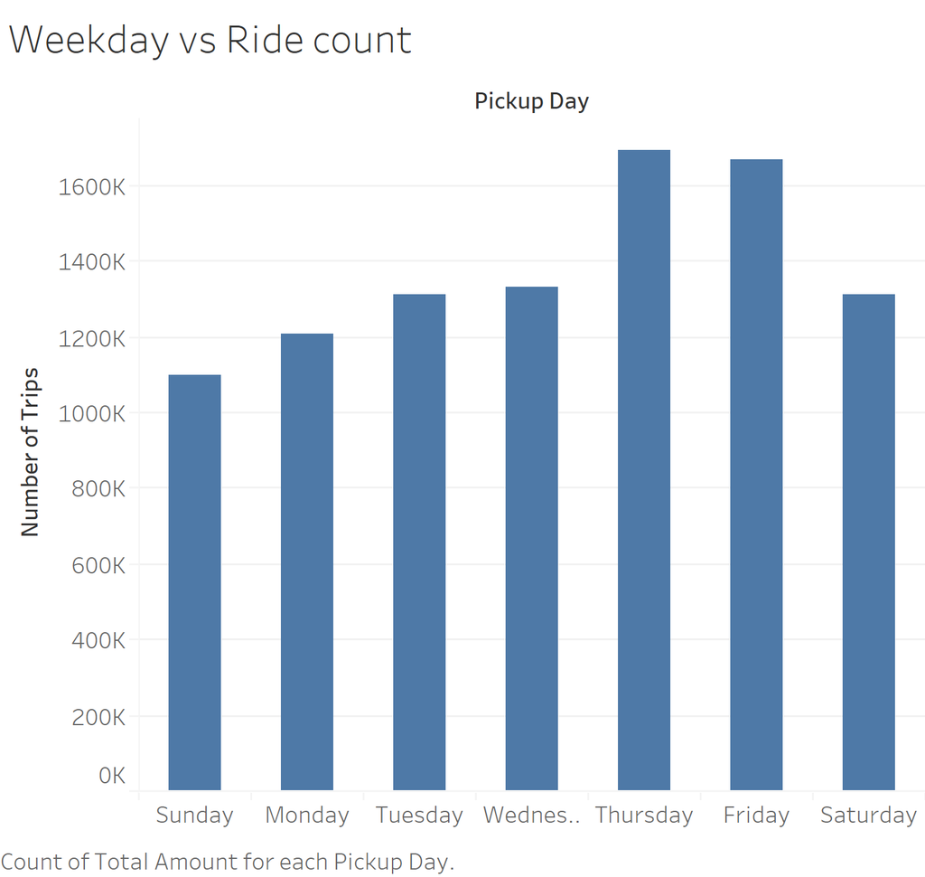

```python
from IPython.display import Image
Image(filename='DayofWeek_RideCount.PNG')
```

From the above results, Thursday and Friday has the highest number of rides and total amount earned.

#### Find number of rides per hour on each day based on hour

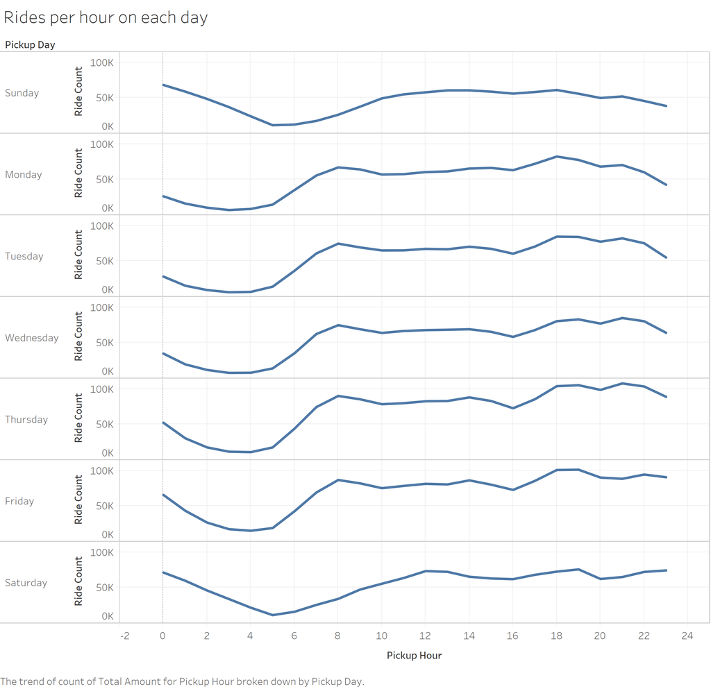

```python
Image(filename='RideCountPerHour_Day.PNG')
```

If the driver needs to get more number of rides, we need to aim for peak hours.

According to the above plot, the following insights can be drawn:

1. Peak hours vary from weekdays to weekends
2. On Weekdays, peak hours are between 7am - 9am and 5pm - 9pm. In the morning, the rides start increasing from 7am and it goes to peak at 8am and the number of rides start decreasing after 8am. In the evening, the peak hours are between 6pm - 8pm and again it goes to peak at 9pm
3. Monday, Tuesday and Wednesday follow similar pattern. Thursday and Friday has a little different pattern compared to other weekdays.
4. On Thurday and Friday, 12am - 2am rides are high and also the peak hour rides are more compared to other weekdays which makes them the highest earning days..
5. When it comes to weekend, 12am - 2am are the peak hours in the morning. 12pm - 1pm and 6pm - 7pm has a good amount of rides

We have to consider one case while driving in peak hours. If the trip duration is very long in Peak hours, the driver is not going to earn profit. Driver gets profit with more short rides because every ride has a minimum fee that has to be paid by customer and surcharges can also be earned if it's a peak hour.

So, we need to find out if the driver has the possibility to drive more short rides in peak hours when compared to short or long rides rest of the day.

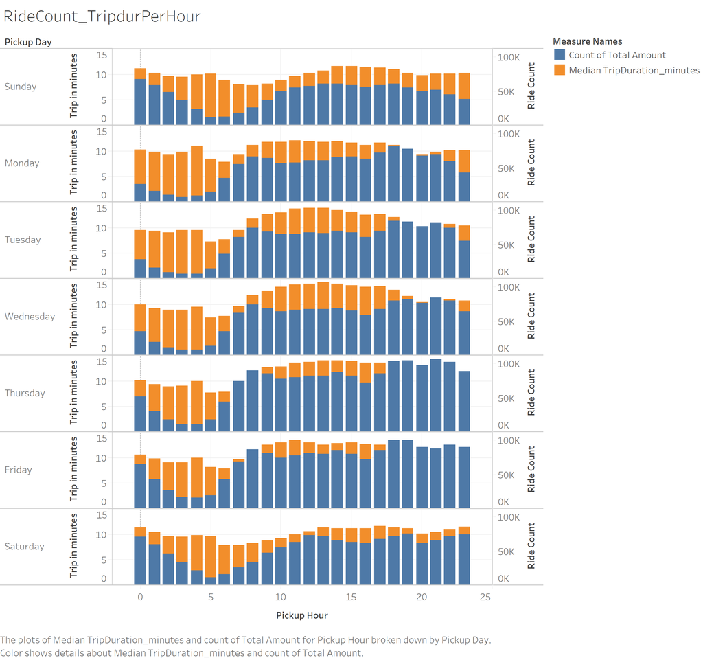

```python
Image(filename='RideCount_TripDurPerHour.PNG')
```

I have plotted number of rides, median of trip duration (minutes) per each pickup hour and Pickup day. I considered median because median gives the accurate center value even when there are any outliers. The orange bar is Trip duration in minutes with values on the left axis and blue bar is Ride count with values on right axis.

As Monday, Tuesday and Wednesday has similar pattern I would like to compare them first. Trip duration is high between 10am - 5pm which does not fall under peak hours considered before. During the peak hours, the duration is around 10 minutes which is not bad. There are short duration trips less than 9 minutes around 5am - 6am but the number of rides recorded are less.

The trip duration for Thursday and Friday have similar pattern with other weekdays. So, I think driving during the peak hours would make some profit for the driver.

In the weekends, the trip durations are a bit less compared to weekdays but it follows the same pattern as weekdays. It is above 10 minutes during 12am - 1am and 12pm - 5pm.

So, it's better to drive around 12am - 2am, 12pm - 1pm and 6pm - 7pm

#### Summarize dataframe to find the number of rides from one zone to another

```python
df_pickupHour = df.groupby(['Borough_Pickup', 'Borough_Dropoff']).agg({'total_amount': ['sum','count']})
df_pickupHour
```

| Borough_Pickup | Borough_Dropoff | total_amount sum | total_amount count |
| --- | --- | --- | --- |
| Bronx | Bronx | 71,914.7600 | 5082 |
|  | Brooklyn | 5,185.4200 | 95 |
|  | EWR | 860.9300 | 7 |
|  | Manhattan | 48,114.0200 | 2567 |
|  | Queens | 11,513.4500 | 268 |
|  | Staten Island | 359.7400 | 3 |
|  | Unknown | 7,024.8900 | 113 |
| Brooklyn | Bronx | 17,338.7500 | 331 |
|  | Brooklyn | 1,287,625.4900 | 99737 |
|  | EWR | 11,762.5100 | 112 |
|  | Manhattan | 951,920.8800 | 40525 |
|  | Queens | 287,043.8700 | 9513 |
|  | Staten Island | 5,214.7900 | 88 |
|  | Unknown | 13,141.4700 | 180 |
| EWR | Brooklyn | 88.8000 | 1 |
|  | EWR | 61,561.1000 | 681 |
|  | Manhattan | 1,573.6100 | 15 |
|  | Queens | 299.7300 | 3 |
|  | Unknown | 446.3000 | 10 |
| Manhattan | Bronx | 1,411,303.9300 | 44583 |
|  | Brooklyn | 7,576,990.7200 | 271752 |
|  | EWR | 1,769,372.2900 | 18136 |
|  | Manhattan | 102,038,858.4323 | 8062013 |
|  | Queens | 13,949,823.7701 | 324873 |
|  | Staten Island | 100,555.6500 | 1268 |
|  | Unknown | 782,624.6800 | 11521 |
| Queens | Bronx | 525,230.0900 | 9461 |
|  | Brooklyn | 3,737,946.2400 | 81083 |
|  | EWR | 82,809.8700 | 561 |
|  | Manhattan | 18,045,755.9800 | 340530 |
|  | Queens | 3,626,209.9100 | 162052 |
|  | Staten Island | 57,502.1900 | 622 |
|  | Unknown | 1,011,745.5700 | 10514 |
| Staten Island | Brooklyn | 555.0500 | 11 |
|  | Manhattan | 481.3000 | 7 |
|  | Queens | 476.0800 | 5 |
|  | Staten Island | 4,510.7700 | 103 |
|  | Unknown | 962.3300 | 5 |
| Unknown | Bronx | 4,662.1400 | 144 |
|  | Brooklyn | 23,670.7600 | 834 |
|  | EWR | 12,646.0600 | 131 |
|  | Manhattan | 258,154.6000 | 16789 |
|  | Queens | 55,026.7400 | 1619 |
|  | Staten Island | 340.2500 | 5 |
|  | Unknown | 2,224,943.9000 | 114196 |

From the above grouping, it can observed that Manhattan has highest number of ride pickups and drop-offs followed by Queens. The top five routes which has highest number of rides and earnings are:

1. Manhattan -> Manhattan
2. Queens -> Manhattan
3. Manhattan -> Queens
4. Manhattan -> Brooklyn
5. Queens -> Queens

```python
df.reset_index(inplace = True)
df.head(5)
```

|  | index | VendorID | tpep_pickup_datetime | tpep_dropoff_datetime | passenger_count | trip_distance | RatecodeID | store_and_fwd_flag | PULocationID | DOLocationID | ... | dropoff_year | Pickup_Month | Pickup_Day | Pickup_Hour | Dropoff_Month | Dropoff_Day | Dropoff_Hour | Borough_Pickup | Borough_Dropoff | tip_rate |
| --- | --- | --- | --- | --- | --- | --- | --- | --- | --- | --- | --- | --- | --- | --- | --- | --- | --- | --- | --- | --- | --- |
| 0 | 0 | 2 | 2017-06-08 07:52:31 | 2017-06-08 08:01:32 | 6 | 1.0300 | 1 | N | 161 | 140 | ... | 2017 | 6 | Thursday | 7 | 6 | Thursday | 8 | Manhattan | Manhattan | 16.6667 |
| 1 | 1 | 1 | 2017-06-09 17:59:47 | 2017-06-09 18:10:44 | 1 | 1.7000 | 1 | N | 161 | 140 | ... | 2017 | 6 | Friday | 17 | 6 | Friday | 18 | Manhattan | Manhattan | 16.6023 |
| 2 | 2 | 1 | 2017-06-09 18:00:46 | 2017-06-09 18:09:10 | 1 | 1.3000 | 1 | N | 161 | 140 | ... | 2017 | 6 | Friday | 18 | 6 | Friday | 18 | Manhattan | Manhattan | 16.5919 |
| 3 | 3 | 1 | 2017-06-09 18:02:09 | 2017-06-09 18:13:21 | 2 | 1.4000 | 1 | N | 161 | 140 | ... | 2017 | 6 | Friday | 18 | 6 | Friday | 18 | Manhattan | Manhattan | 0.0000 |
| 4 | 4 | 1 | 2017-06-09 18:05:18 | 2017-06-09 18:20:21 | 1 | 2.3000 | 1 | N | 161 | 140 | ... | 2017 | 6 | Friday | 18 | 6 | Friday | 18 | Manhattan | Manhattan | 0.0000 |

5 rows × 30 columns

### Linear Optimization:

I am going to use Linear Optimization to solve this problem. Linear Programming, also called linear optimization, involves maximizing or minimizing a linear objective function, subject to a set of linear inequality or equality constraints

As we need to maximize the income, our problem is to maximize the linear objective function. Hence, we need to create the below model:

Objective: Maximize the taxi driver income

LP Form: Maximization

Decision Variables: I have considered rides as decision variables. Based on these rides, I would like to find the top combination of rides

#### Create the Linear programming Problem using Pulp

```python
prob = pulp.LpProblem('MaximizeIncome', pulp.LpMaximize)
```

#### Create Decision variables

```python
decision_variables = []
for rownum, row in df.iterrows():
    variable = str('x' + str(row['index']))
    variable = pulp.LpVariable(str(variable), lowBound = 0, upBound = 1, cat= 'Integer') #binary variables
    decision_variables.append(variable)

print ("Total number of decision_variables: " + str(len(decision_variables)))
```

```
Total number of decision_variables: 9632149
```

#### Define Objective Function: Maximizing the Income by maximizing the total_amount

```python
total_cost = ""
for rownum, row in df.iterrows():
    formula = row['total_amount']*decision_variables[rownum]
    total_cost += formula

prob += total_cost
```

```python
num_hours = 10
total_hours = ""
for rownum, row in df.iterrows():
    formula = row['trip_duration']*decision_variables[rownum]
    total_hours += formula

#As the trip_duration is seconds in the dataset, convert hours to seconds
hours_tosec = num_hours*3600
prob += (total_hours == hours_tosec)
```

```python
prob.writeLP("MaximizeIncome.lp" )
```

#### Solve the Problem using GLPK solver and find the status

```python
prob.solve(GLPK_CMD(path = r"C:\Users\navee\AppData\Local\Continuum\anaconda3\Lib\site-packages\pulp\solverdir\glpk-4.65\w64\glpsol.exe"))

print("Status:", LpStatus[prob.status])
print("Optimal Solution to the problem: ", value(prob.objective))
```

```
Status: Optimal
Optimal Solution to the problem:  1148386.3900001075
```

The problem is solved and optimal solution is obtained. Now, get all the variables from problem to check the decision variable

If value of variable is 1 (among binary values 0 and 1), then store the index in set

```python
index_name = set()

for v in prob.variables():
    if v.varValue == 1:
        st = v.name
        index_name.add(int(st[len('x'):]))
```

Create a column decision and update the value with 0 or 1 based on the index

```python
for row in df.itertuples():
    if (row.Index in index_name):
        df.at[row.Index, 'decision'] = 1
    else:
        df.at[row.Index, 'decision'] = 0
```

Create a dataframe_result with all the records with decision 1. That means all those records with decision 1 is the maximum combination obtained for 10 hours

```python
df_result = df[df['decision'] == 1]
```

```python
df_result.to_csv('df_result.csv', encoding='utf-8', index=False)
```

```python
df_result.describe()
```

|  | index | VendorID | passenger_count | trip_distance | RatecodeID | PULocationID | DOLocationID | payment_type | fare_amount | extra | ... | total_amount | trip_duration | pickup_year | dropoff_year | Pickup_Month | Pickup_Hour | Dropoff_Month | Dropoff_Hour | tip_rate | decision |
| --- | --- | --- | --- | --- | --- | --- | --- | --- | --- | --- | --- | --- | --- | --- | --- | --- | --- | --- | --- | --- | --- |
| count | 6,280.0000 | 6,280.0000 | 6,280.0000 | 6,280.0000 | 6,280.0000 | 6,280.0000 | 6,280.0000 | 6,280.0000 | 6,280.0000 | 6,280.0000 | ... | 6,280.0000 | 6,280.0000 | 6,280.0000 | 6,280.0000 | 6,280.0000 | 6,280.0000 | 6,280.0000 | 6,280.0000 | 6,280.0000 | 6,280.0000 |
| mean | 5,645,839.4236 | 1.6994 | 1.4185 | 0.8141 | 3.3457 | 184.3049 | 174.3871 | 1.3381 | 171.1930 | 0.4498 | ... | 182.8641 | 5.7325 | 2,017.0000 | 2,017.0000 | 6.0000 | 13.0576 | 6.0000 | 13.0584 | 11.6686 | 1.0000 |
| std | 3,142,062.5203 | 0.4586 | 0.9882 | 9.8773 | 1.6083 | 78.6108 | 77.8910 | 0.6112 | 7,956.7137 | 1.2904 | ... | 7,956.6310 | 10.7068 | 0.0000 | 0.0000 | 0.0000 | 6.6625 | 0.0000 | 6.6629 | 16.7438 | 0.0000 |
| min | 21,883.0000 | 1.0000 | 1.0000 | 0.0000 | 1.0000 | 1.0000 | 1.0000 | 1.0000 | 0.0000 | 0.0000 | ... | 0.3000 | 0.0000 | 2,017.0000 | 2,017.0000 | 6.0000 | 0.0000 | 6.0000 | 0.0000 | 0.0000 | 1.0000 |
| 25% | 1,777,354.0000 | 1.0000 | 1.0000 | 0.0000 | 2.0000 | 132.0000 | 132.0000 | 1.0000 | 52.0000 | 0.0000 | ... | 52.8000 | 3.0000 | 2,017.0000 | 2,017.0000 | 6.0000 | 8.0000 | 6.0000 | 8.0000 | 0.0000 | 1.0000 |
| 50% | 6,979,527.0000 | 2.0000 | 1.0000 | 0.0000 | 2.0000 | 186.0000 | 162.0000 | 1.0000 | 52.0000 | 0.0000 | ... | 65.4850 | 4.0000 | 2,017.0000 | 2,017.0000 | 6.0000 | 14.0000 | 6.0000 | 14.0000 | 10.4790 | 1.0000 |
| 75% | 8,050,623.0000 | 2.0000 | 1.0000 | 0.0100 | 5.0000 | 264.0000 | 264.0000 | 2.0000 | 67.0000 | 0.0000 | ... | 78.9600 | 7.0000 | 2,017.0000 | 2,017.0000 | 6.0000 | 18.0000 | 6.0000 | 18.0000 | 16.6667 | 1.0000 |
| max | 9,632,132.0000 | 2.0000 | 9.0000 | 733.4000 | 6.0000 | 265.0000 | 265.0000 | 4.0000 | 630,461.8200 | 4.5000 | ... | 630,463.1200 | 682.0000 | 2,017.0000 | 2,017.0000 | 6.0000 | 23.0000 | 6.0000 | 23.0000 | 99.8180 | 1.0000 |

8 rows × 24 columns

```python
dfresult_dayGroup = df_result.groupby(['Pickup_Day']).agg({'total_amount': ['sum','count']})
dfresult_dayGroup
```

| Pickup_Day | total_amount sum | total_amount count |
| --- | --- | --- |
| Friday | 89,983.1400 | 1110 |
| Monday | 72,313.2800 | 846 |
| Saturday | 61,034.6700 | 817 |
| Sunday | 79,380.3500 | 1021 |
| Thursday | 75,647.8300 | 948 |
| Tuesday | 693,932.8700 | 747 |
| Wednesday | 76,094.2500 | 791 |

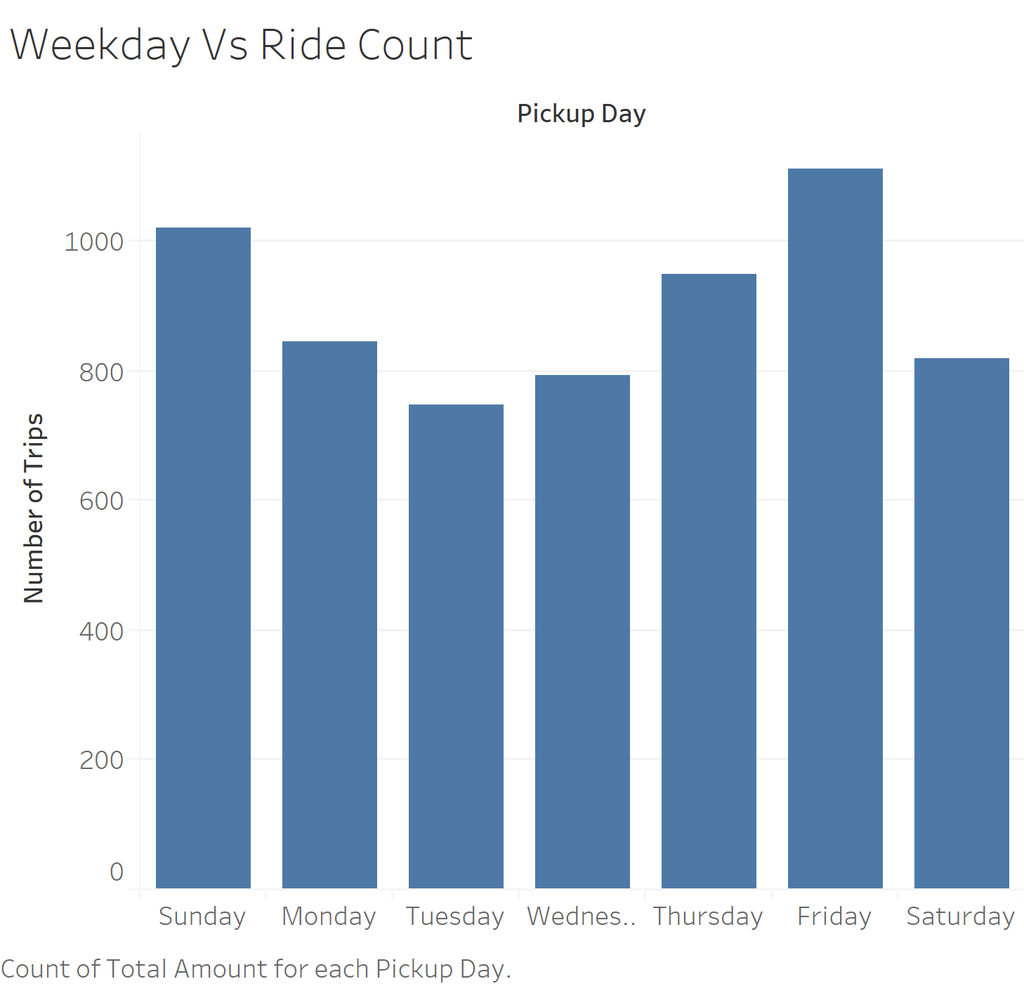

```python
Image(filename='Result_DayofWeek_RideCount.PNG')
```

According to the above results, Friday has the highest number of rides followed by Sunday, Thursday and Monday

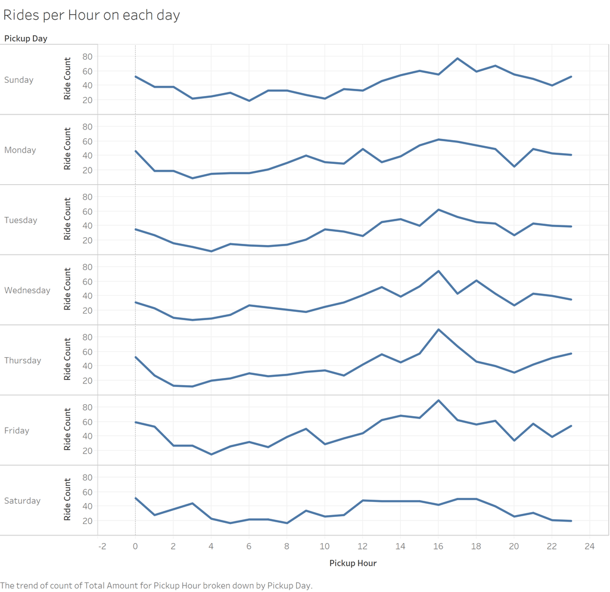

```python
Image(filename='Result_RideCountPerHour_Day.PNG')
```

The above trend says that the peak hours are around 4PM in the evening. Most of the rides are recorded in that time period. Thursday and Friday also has peak hours at 12 am.

On Saturday, lot of rides are recorded at 12am, 3am and 12pm - 4pm On Sunday, the peak hours are at 5pm

```python
dfresult_pickupHour = df_result.groupby(['Borough_Pickup', 'Borough_Dropoff']).agg({'total_amount': ['sum','count']})
dfresult_pickupHour
```

| Borough_Pickup | Borough_Dropoff | total_amount sum | total_amount count |
| --- | --- | --- | --- |
| Bronx | Bronx | 2,141.0400 | 35 |
| Brooklyn | Brooklyn | 17,024.9500 | 211 |
|  | Queens | 52.8000 | 1 |
| EWR | EWR | 16,570.5000 | 152 |
| Manhattan | Bronx | 52.8000 | 1 |
|  | Brooklyn | 68.2600 | 2 |
|  | Manhattan | 797,558.1200 | 2402 |
|  | Unknown | 169.0600 | 3 |
| Queens | Manhattan | 207.3600 | 3 |
|  | Queens | 107,106.7100 | 1322 |
|  | Unknown | 530.5900 | 5 |
| Staten Island | Staten Island | 1,181.2700 | 12 |
| Unknown | Bronx | 267.6600 | 5 |
|  | Brooklyn | 479.4000 | 9 |
|  | EWR | 2,612.5500 | 24 |
|  | Manhattan | 18,144.9200 | 310 |
|  | Queens | 11,224.9400 | 171 |
|  | Unknown | 172,993.4600 | 1612 |

From the above results, it can be observed that the most of the rides are in below routes:

1. Manhattan -> Manhattan (2402 rides)
2. Unknown -> Unknown (1612 rides - which doesn't have specified look up in the zone look up table)
3. Queens -> Queens (1322 rides)

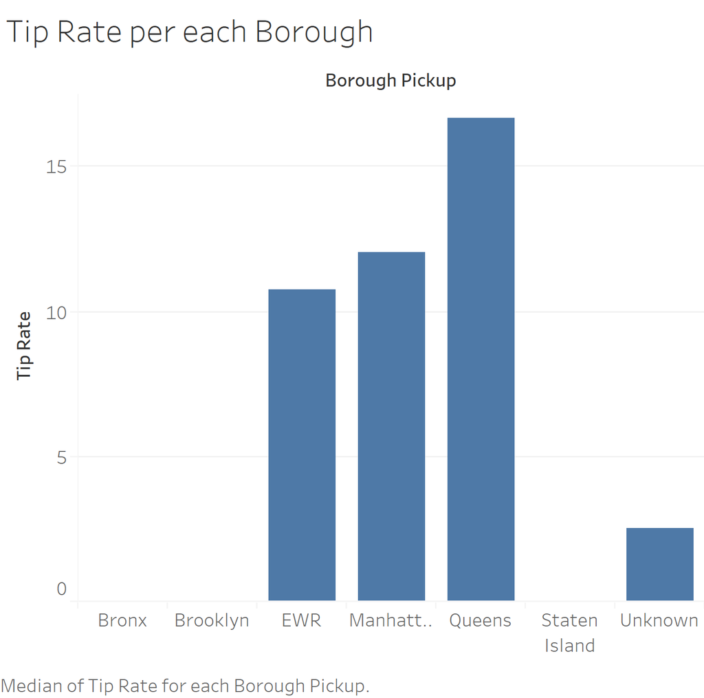

```python
Image(filename='Result_TipRateBorough.PNG')
```

Queens has the highest tip rate followed by Manhattan and EWR. So, it would be more profit to start rides from Queens and Manhattan